# Reporte

# Introduction

This project has the objective of performing a Differential Gene Expression (DGE) analysis to investigate the function of the long intergenic non-coding RNA, AC093323.3. In this study, H460 lung cancer cells were used as the model system. The cells were divided into two groups: one treated with AC093323.3-targeting siRNAs and the other with a non-target (scrambled) siRNA as a negative control. The total RNA sequences were extracted from three biological replicates of non-target siRNA and AC093323.3 siRNA.

## Previous installations

If not intalled Biocounductor, install it with the following command

```r
if (!requireNamespace("BiocManager", quietly = TRUE))
  install.packages("BiocManager")

# Install other packages
BiocManager::install(
  c(
    "recount",
    "edgeR",
    "ggplot2",
    "limma",
    "pheatmap",
    "RColorBrewer"
    )
  )
```

[output not shown]

[output not shown]

```
Update all/some/none? [a/s/n]:
```

```r
n
```

## Download data

First, we need to download the data from the SRP150320 project.

```r
# Load recount3 package
library(recount3)
# Create the RangedSummarizedExperiment object for the SRP150320 data.
rse_gene_SRP150320 <- create_rse(subset(available_projects(), project == "SRP150320"))
```

[output not shown]

Visualize and explore data

```r
rse_gene_SRP150320
```

```
class: RangedSummarizedExperiment
dim: 28527 24
metadata(8): time_created recount3_version ... annotation
  recount3_url
assays(2): raw_counts counts
rownames(28527): ENSG00000223972.5 ENSG00000278267.1 ...
  ENSG00000231514.1 ENSG00000237917.1
rowData names(10): source type ... havana_gene tag
colnames(24): SRR7293909 SRR7293910 ... SRR7293931 SRR7293932
colData names(184): rail_id external_id ... sra_attribute.sirna
  sra_attribute.source_name
```

## Data Proccesing

```r
# Transform the recount3 data from counts per nucleotide into counts per lecture
assay(rse_gene_SRP150320, "counts") <- compute_read_counts(rse_gene_SRP150320)

rse_gene_SRP150320 <- expand_sra_attributes(rse_gene_SRP150320)

# Maintain only the columns that start with sra_attribute
colData(rse_gene_SRP150320)[
  ,
  grepl("^sra_attribute", colnames(colData(rse_gene_SRP150320)))
]
```

```
DataFrame with 24 rows and 12 columns
           sra_attribute.cell_line sra_attribute.replicate
                          <factor>                <factor>
SRR7293909                    H460                       1
SRR7293910                    H460                       1
SRR7293911                    H460                       1
SRR7293912                    H460                       1
SRR7293913                    H460                       2
...                            ...                     ...
SRR7293928                    H460                       2
SRR7293929                    H460                       3
SRR7293930                    H460                       3
SRR7293931                    H460                       3
SRR7293932                    H460                       3
           sra_attribute.sirna sra_attribute.source_name
                      <factor>                  <factor>
SRR7293909    non-target siRNA         Lung cancer cells
SRR7293910    non-target siRNA         Lung cancer cells
SRR7293911    non-target siRNA         Lung cancer cells
SRR7293912    non-target siRNA         Lung cancer cells
SRR7293913    non-target siRNA         Lung cancer cells
...                        ...                       ...
SRR7293928    AC093323.3 siRNA         Lung cancer cells
SRR7293929    AC093323.3 siRNA         Lung cancer cells
SRR7293930    AC093323.3 siRNA         Lung cancer cells
SRR7293931    AC093323.3 siRNA         Lung cancer cells
SRR7293932    AC093323.3 siRNA         Lung cancer cells
           sra_attribute.cell_line sra_attribute.replicate
                       <character>             <character>
SRR7293909                    H460                       1
SRR7293910                    H460                       1
SRR7293911                    H460                       1
SRR7293912                    H460                       1
SRR7293913                    H460                       2
...                            ...                     ...
SRR7293928                    H460                       2
SRR7293929                    H460                       3
SRR7293930                    H460                       3
SRR7293931                    H460                       3
SRR7293932                    H460                       3
```

[output cut: 24 more lines]

```
SRR7293931                    H460                       3
SRR7293932                    H460                       3
           sra_attribute.sirna sra_attribute.source_name
                   <character>               <character>
SRR7293909    non-target siRNA         Lung cancer cells
SRR7293910    non-target siRNA         Lung cancer cells
SRR7293911    non-target siRNA         Lung cancer cells
SRR7293912    non-target siRNA         Lung cancer cells
SRR7293913    non-target siRNA         Lung cancer cells
...                        ...                       ...
SRR7293928    AC093323.3 siRNA         Lung cancer cells
SRR7293929    AC093323.3 siRNA         Lung cancer cells
SRR7293930    AC093323.3 siRNA         Lung cancer cells
SRR7293931    AC093323.3 siRNA         Lung cancer cells
SRR7293932    AC093323.3 siRNA         Lung cancer cells
```

```r
# Procesar los datos, convertir las columnas de sra_attribute en factores
rse_gene_SRP150320$sra_attribute.source_name <- factor(rse_gene_SRP150320$sra_attribute.source_name)
rse_gene_SRP150320$sra_attribute.sirna <- factor(rse_gene_SRP150320$sra_attribute.sirna)
rse_gene_SRP150320$sra_attribute.replicate <- factor(rse_gene_SRP150320$sra_attribute.replicate)
rse_gene_SRP150320$sra_attribute.cell_line <- factor(rse_gene_SRP150320$sra_attribute.cell_line)


# Resumen de las variables de sra_attribute
summary(as.data.frame(colData(rse_gene_SRP150320)[
  ,
  grepl("^sra_attribute.[source_name|sirna|replicate|cell_line]", colnames(colData(rse_gene_SRP150320)))
]))
```

```
 sra_attribute.cell_line sra_attribute.replicate       sra_attribute.sirna
 H460:24                 1:8                     AC093323.3 siRNA:12
                         2:8                     non-target siRNA:12
                         3:8
     sra_attribute.source_name sra_attribute.cell_line.1
 Lung cancer cells:24          Length:24
                               Class :character
                               Mode  :character
 sra_attribute.replicate.1 sra_attribute.sirna.1 sra_attribute.source_name.1
 Length:24                 Length:24             Length:24
 Class :character          Class :character      Class :character
 Mode  :character          Mode  :character      Mode  :character
 sra_attribute.cell_line.2 sra_attribute.replicate.2 sra_attribute.sirna.2
 Length:24                 Length:24                 Length:24
 Class :character          Class :character          Class :character
 Mode  :character          Mode  :character          Mode  :character
 sra_attribute.source_name.2
 Length:24
 Class :character
 Mode  :character
```

Usaremos activamente las variables de sra_attribute.sirna, 12 konckdown con AC093323.3 siRNA, y 12 de control; y sra_attribute.replicate, que recoje el número del replicado biológico de la muestra.

### Sample Quality Control Analysis

```r
rse_gene_SRP150320$assigned_gene_prop <- rse_gene_SRP150320$recount_qc.gene_fc_count_all.assigned / rse_gene_SRP150320$recount_qc.gene_fc_count_all.total

summary(rse_gene_SRP150320$assigned_gene_prop)
```

```
   Min. 1st Qu.  Median    Mean 3rd Qu.    Max.
 0.8061  0.8132  0.8172  0.8162  0.8210  0.8232
```

```r
with(colData(rse_gene_SRP150320), tapply(assigned_gene_prop, sra_attribute.sirna, summary))
```

```
$`AC093323.3 siRNA`
   Min. 1st Qu.  Median    Mean 3rd Qu.    Max.
 0.8061  0.8066  0.8152  0.8148  0.8225  0.8232

$`non-target siRNA`
   Min. 1st Qu.  Median    Mean 3rd Qu.    Max.
 0.8128  0.8133  0.8190  0.8177  0.8209  0.8212
```

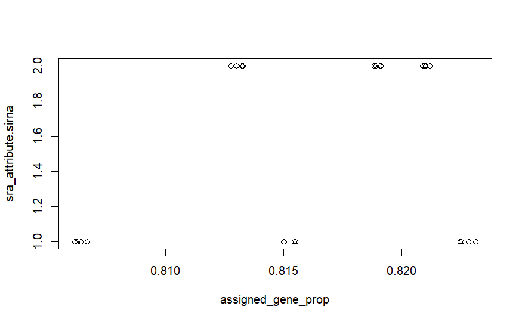

```r
with(colData(rse_gene_SRP150320), plot(assigned_gene_prop, sra_attribute.sirna))
```

Like this, we can note that due to the minimal value of the assigned_gene_prop is 0.8061, which is a pretty good measure (means that the 80% of the genes in a sample were able to be assigned to a gene), then all sample have good quality.

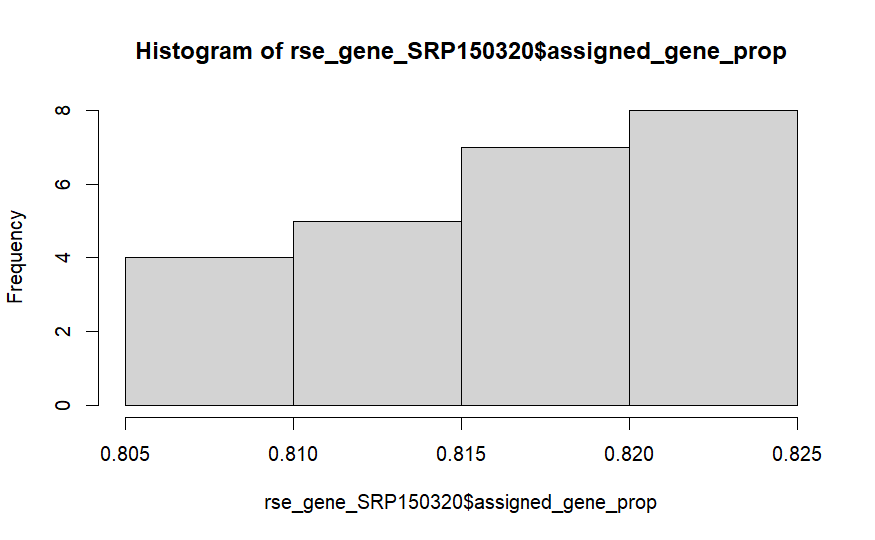

```r
rse_gene_SRP150320_unfiltered <- rse_gene_SRP150320

hist(rse_gene_SRP150320$assigned_gene_prop)
```

```r
table(rse_gene_SRP150320$assigned_gene_prop < 0.3)
```

```
FALSE
   24
```

### Gene filtering

```r
# Compute the medium expression levels of each gene with the counts
gene_means <- rowMeans(assay(rse_gene_SRP150320, "counts"))

summary(gene_means)
```

```
    Min.  1st Qu.   Median     Mean  3rd Qu.     Max.
    0.12     0.96    14.75   209.97   162.88 64411.71
```

```r
# Select only the genes
rse_gene_SRP150320 <- rse_gene_SRP150320[gene_means > 0.1, ]
# Final dimentions
dim(rse_gene_SRP150320)
```

```
[1] 28527    24
```

```r
# Kept gene percentage
round(nrow(rse_gene_SRP150320) / nrow(rse_gene_SRP150320_unfiltered) * 100, 2)
```

```
[1] 100
```

## RNA-seq data proccessing

### Data Normalization

```r
# Load edgeR package
library("edgeR")
# Object for Differential Gene Expresion
dge <- DGEList(
  counts = assay(rse_gene_SRP150320, "counts"),
  genes = rowData(rse_gene_SRP150320)
)
# Normalization
dge <- calcNormFactors(dge)
```

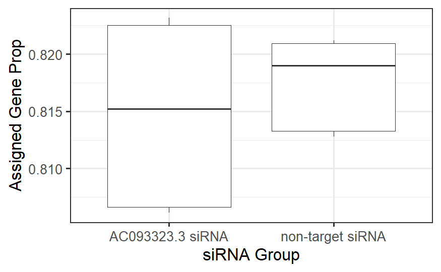

```r
library("ggplot2")
ggplot(as.data.frame(colData(rse_gene_SRP150320)), aes(y = assigned_gene_prop, x = sra_attribute.sirna)) +
  geom_boxplot() +
  theme_bw(base_size = 20) +
  ylab("Assigned Gene Prop") +
  xlab("siRNA Group")
```

### Build statistical model

```r
mod <- model.matrix(~ sra_attribute.sirna + sra_attribute.replicate + assigned_gene_prop,
                    data = colData(rse_gene_SRP150320)
)
colnames(mod)
```

```
[1] "(Intercept)"                         "sra_attribute.sirnanon-target siRNA" "sra_attribute.replicate2"            "sra_attribute.replicate3"
[5] "assigned_gene_prop"
```

## Diferrential Expression Analysis

### Statistical analysis with limma

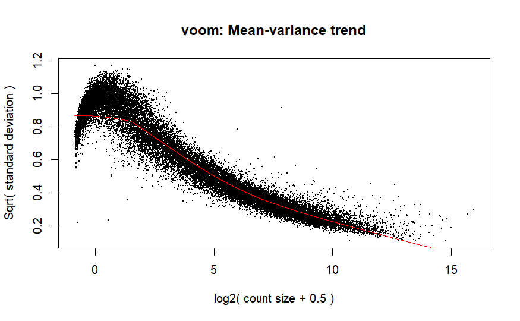

```r
# Load library
library("limma")

# Transform count data to log2 counts-per-million (logCPM)
vGene <- voom(dge, mod, plot = TRUE)
```

```r
# Adjust a lineal model and apply a Bayesian correction
eb_results <- eBayes(lmFit(vGene))

# Extract Differentially Expressed Genes (DEGs)
de_results <- topTable(
  eb_results,
  coef = 1,
  number = nrow(rse_gene_SRP150320),
  sort.by = "none"
)

dim(de_results)
```

```
[1] 28527    16
```

```r
head(de_results)
```

|  | source | type | bp_length | phase | gene_id | gene_type | gene_name | level | havana_gene | tag | logFC | AveExpr | t | P.Value | adj.P.Val | B |
| --- | --- | --- | --- | --- | --- | --- | --- | --- | --- | --- | --- | --- | --- | --- | --- | --- |
| ENSG00000223972.5 | HAVANA | gene | 1735 | NA | ENSG00000223972.5 | transcribed_unprocessed_pseudogene | DDX11L1 | 2 | OTTHUMG00000000961.2 | NA | -0.9799795 | -2.466070 | -0.02263635 | 0.98207936 | 0.9927574 | -4.601349 |
| ENSG00000278267.1 | ENSEMBL | gene | 68 | NA | ENSG00000278267.1 | miRNA | MIR6859-1 | 3 | NA | NA | 18.5804102 | -2.456818 | 0.52174345 | 0.60540214 | 0.8346919 | -4.599651 |
| ENSG00000227232.5 | HAVANA | gene | 1351 | NA | ENSG00000227232.5 | unprocessed_pseudogene | WASH7P | 2 | OTTHUMG00000000958.1 | NA | 24.9085124 | 2.936906 | 2.59663274 | 0.01404764 | 0.1050976 | -4.278907 |
| ENSG00000243485.5 | HAVANA | gene | 1021 | NA | ENSG00000243485.5 | lincRNA | MIR1302-2HG | 2 | OTTHUMG00000000959.2 | ncRNA_host | -37.8981198 | -3.020472 | -1.02556912 | 0.31270059 | 0.6234711 | -4.594850 |
| ENSG00000237613.2 | HAVANA | gene | 1219 | NA | ENSG00000237613.2 | lincRNA | FAM138A | 2 | OTTHUMG00000000960.1 | NA | 45.7568888 | -3.121845 | 1.30734131 | 0.20031029 | 0.5073875 | -4.591006 |
| ENSG00000239945.1 | HAVANA | gene | 1319 | NA | ENSG00000239945.1 | lincRNA | RP11-34P13.8 | 2 | OTTHUMG00000001097.2 | overlapping_locus | -10.4110536 | -3.350672 | -0.31644408 | 0.75369785 | 0.9092999 | -4.600586 |

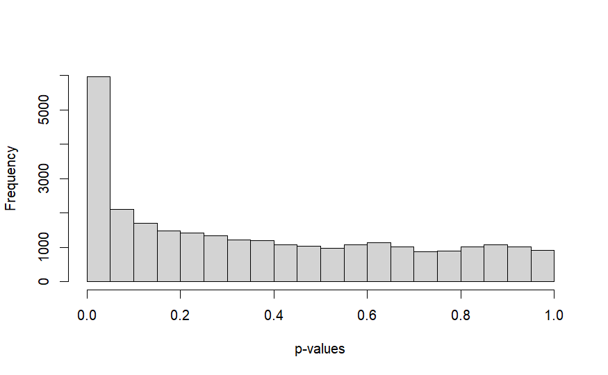

```r
hist(de_results$P.Value, xlab = "p-values", main = "")
```

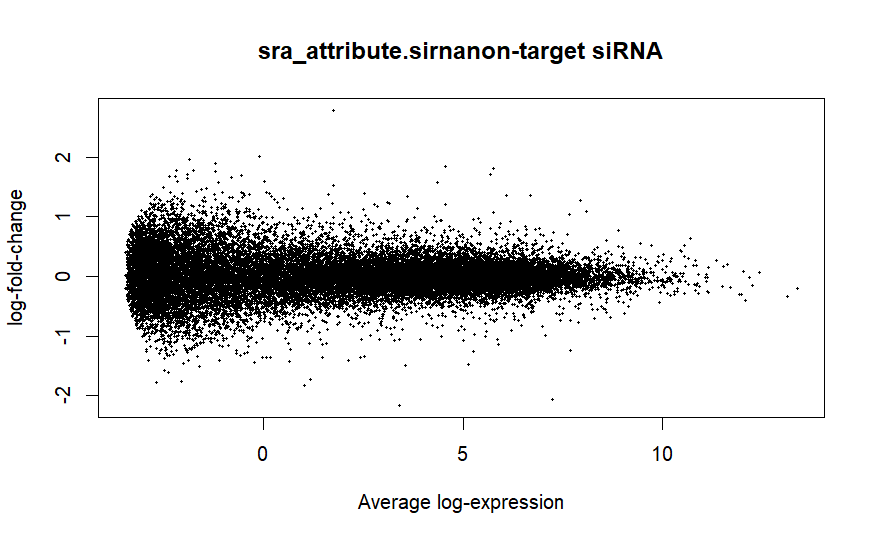

```r
## Visualicemos los resultados estadísticos
plotMA(eb_results, coef = 2)
```

```r
de_genes <- de_results[which(de_results$adj.P.Val < 0.05),]
dim(de_genes)
```

```
[1] 2801   16
```

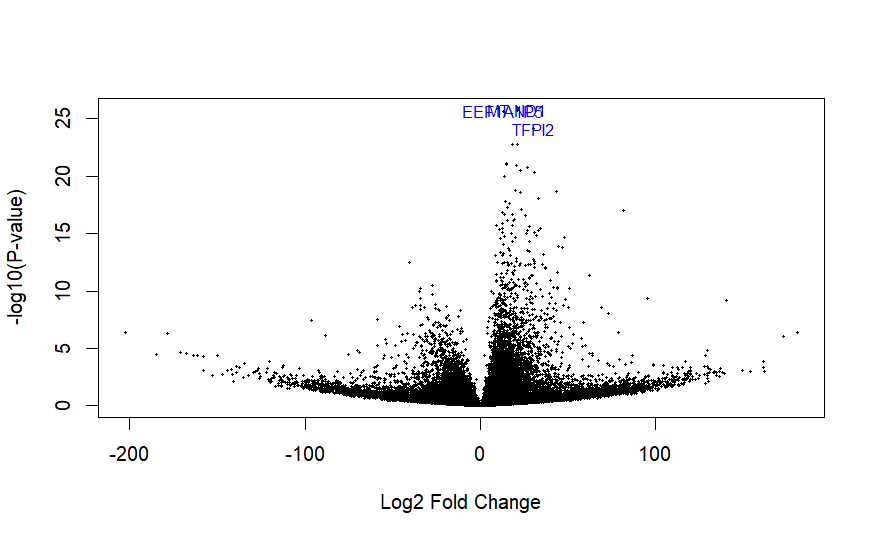

```r
volcanoplot(eb_results, coef = 1, highlight = 3, names = de_results$gene_name)
```